# ECOLE D’ETE CIST 2022

Inventaire préparatoire des données

Claude Grasland (Université de Paris (Diderot), UMR 8504 Géographie-cités, FR 2007 CIST)

# 1 DONNEES INTERNATIONALES

## 1.1 Banque Mondiale

Supposons que l’on souhaite télécharger la population, le PIB et les émisssions de CO2 des pays du monde de 2000 à 2015. Plutôt que d’aller chercher des fichiers sur un site web, nous allons utiliser une API proposée par la Banque Mondiale qui permet de télécharger les données facilement et surtout de les mettre à jour régulièrement. Pour cela on va installer le package R correspondant à l’API `wbstats` de la Banque mondiale.

https://cran.r-project.org/web/packages/wbstats/vignettes/Using_the_wbstats_package.html

Au moment du chargement du package, il est créé un fichier wb_cachelist qui fournit l’ensemble des donnes disponibles sous la forme d’une liste de tableaux de méta-données.

```
List of 8
   $ countries    : tibble [304 x 18] (S3: tbl_df/tbl/data.frame)
   $ indicators   : tibble [16,649 x 8] (S3: tbl_df/tbl/data.frame)
   $ sources      : tibble [63 x 9] (S3: tbl_df/tbl/data.frame)
   $ topics       : tibble [21 x 3] (S3: tbl_df/tbl/data.frame)
   $ regions      : tibble [48 x 4] (S3: tbl_df/tbl/data.frame)
   $ income_levels: tibble [7 x 3] (S3: tbl_df/tbl/data.frame)
   $ lending_types: tibble [4 x 3] (S3: tbl_df/tbl/data.frame)
   $ languages    : tibble [23 x 3] (S3: tbl_df/tbl/data.frame)
```

### 1.1.1 Le tableau “countries”

Il fournit des renseignements de base sur les différents pays, leurs codes, etc.

```
tibble [304 x 18] (S3: tbl_df/tbl/data.frame)
   $ iso3c             : chr [1:304] "ABW" "AFG" "AFR" "AGO" ...
   $ iso2c             : chr [1:304] "AW" "AF" "A9" "AO" ...
   $ country           : chr [1:304] "Aruba" "Afghanistan" "Africa" "Angola" ...
   $ capital_city      : chr [1:304] "Oranjestad" "Kabul" NA "Luanda" ...
   $ longitude         : num [1:304] -70 69.2 NA 13.2 19.8 ...
   $ latitude          : num [1:304] 12.52 34.52 NA -8.81 41.33 ...
   $ region_iso3c      : chr [1:304] "LCN" "SAS" NA "SSF" ...
   $ region_iso2c      : chr [1:304] "ZJ" "8S" NA "ZG" ...
   $ region            : chr [1:304] "Latin America & Caribbean" "South Asia" "Aggregates" "Sub-Saharan Africa" ...
   $ admin_region_iso3c: chr [1:304] NA "SAS" NA "SSA" ...
   $ admin_region_iso2c: chr [1:304] NA "8S" NA "ZF" ...
   $ admin_region      : chr [1:304] NA "South Asia" NA "Sub-Saharan Africa (excluding high income)" ...
   $ income_level_iso3c: chr [1:304] "HIC" "LIC" NA "LMC" ...
   $ income_level_iso2c: chr [1:304] "XD" "XM" NA "XN" ...
   $ income_level      : chr [1:304] "High income" "Low income" "Aggregates" "Lower middle income" ...
   $ lending_type_iso3c: chr [1:304] "LNX" "IDX" NA "IBD" ...
   $ lending_type_iso2c: chr [1:304] "XX" "XI" NA "XF" ...
   $ lending_type      : chr [1:304] "Not classified" "IDA" "Aggregates" "IBRD" ...
```

Le tableau comporte 304 observation et il mélange des pays (France), des fragments de pays (Réunion) et des agrégats de pays (Europe). Il faudra donc bien faire attention lors de l’extraction à réfléchir à ce que l’on souhaite utiliser. Par exemple, si l’on veut juste les pays :

| iso3c | country | capital_city | latitude | longitude | region | income_level |
| --- | --- | --- | --- | --- | --- | --- |
| ABW | Aruba | Oranjestad | 12.51670 | -70.0167 | Latin America & Caribbean | High income |
| AFG | Afghanistan | Kabul | 34.52280 | 69.1761 | South Asia | Low income |
| AGO | Angola | Luanda | -8.81155 | 13.2420 | Sub-Saharan Africa | Lower middle income |
| ALB | Albania | Tirane | 41.33170 | 19.8172 | Europe & Central Asia | Upper middle income |
| AND | Andorra | Andorra la Vella | 42.50750 | 1.5218 | Europe & Central Asia | High income |
| ARE | United Arab Emirates | Abu Dhabi | 24.47640 | 54.3705 | Middle East & North Africa | High income |

### 1.1.2 Le tableau indicators

Il comporte pas loin de 17000 variables … Autant dire qu’il est difficile de l’explorer facilement si l’on ne sait pas ce que l’on cherche.

```
[1] 16649     8
```

| indicator_id | indicator | unit | indicator_desc | source_org | topics | source_id | source |
| --- | --- | --- | --- | --- | --- | --- | --- |
| 1.0.HCount.1.90usd | Poverty Headcount ($1.90 a day) | NA | The poverty headcount index measures the proportion of the population with daily per capita income (in 2011 PPP) below the poverty line. | LAC Equity Lab tabulations of SEDLAC (CEDLAS and the World Bank). | 11 , Poverty | 37 | LAC Equity Lab |
| 1.0.HCount.2.5usd | Poverty Headcount ($2.50 a day) | NA | The poverty headcount index measures the proportion of the population with daily per capita income (in 2005 PPP) below the poverty line. | LAC Equity Lab tabulations of SEDLAC (CEDLAS and the World Bank). | 11 , Poverty | 37 | LAC Equity Lab |
| 1.0.HCount.Mid10to50 | Middle Class ($10-50 a day) Headcount | NA | The poverty headcount index measures the proportion of the population with daily per capita income (in 2005 PPP) below the poverty line. | LAC Equity Lab tabulations of SEDLAC (CEDLAS and the World Bank). | 11 , Poverty | 37 | LAC Equity Lab |
| 1.0.HCount.Ofcl | Official Moderate Poverty Rate-National | NA | The poverty headcount index measures the proportion of the population with daily per capita income below the official poverty line developed by each country. | LAC Equity Lab tabulations of data from National Statistical Offices. | 11 , Poverty | 37 | LAC Equity Lab |
| 1.0.HCount.Poor4uds | Poverty Headcount ($4 a day) | NA | The poverty headcount index measures the proportion of the population with daily per capita income (in 2005 PPP) below the poverty line. | LAC Equity Lab tabulations of SEDLAC (CEDLAS and the World Bank). | 11 , Poverty | 37 | LAC Equity Lab |
| 1.0.HCount.Vul4to10 | Vulnerable ($4-10 a day) Headcount | NA | The poverty headcount index measures the proportion of the population with daily per capita income (in 2005 PPP) below the poverty line. | LAC Equity Lab tabulations of SEDLAC (CEDLAS and the World Bank). | 11 , Poverty | 37 | LAC Equity Lab |

#### 1.1.2.1 Recherche du code d’un indicateur

Supposons qu’on recherche les données récentes sur les émissions de CO2. On va utiliser le mot-clé *CO2* pour rechercher les variables correspondantes dans le catalogue à l’aide de la fonction `wbsearch`, ce qui donne 45 réponses

|  | indicatorID | indicator |
| --- | --- | --- |
| 5294 | EN.ATM.CO2E.CP.KT | CO2 emissions from cement production (thousand metric tons) |
| 5295 | EN.ATM.CO2E.EG.ZS | CO2 intensity (kg per kg of oil equivalent energy use) |
| 5296 | EN.ATM.CO2E.FF.KT | CO2 emissions from fossil-fuels, total (thousand metric tons) |
| 5297 | EN.ATM.CO2E.FF.ZS | CO2 emissions from fossil-fuels (% of total) |
| 5298 | EN.ATM.CO2E.GDP | CO2 emissions, industrial (kg per 1987 US$ of GDP) |
| 5299 | EN.ATM.CO2E.GF.KT | CO2 emissions from gaseous fuel consumption (kt) |

On va finalement trouver le code de la variable recherchée

- *EN.ATM.CO2E.KT* : émissions de CO2 en kilotonnes

#### 1.1.2.2 Extraction des métadonnées

Une fois que l’on pense connaître le code de nos variables, on peut extraire les métadonnés pour vérifier qu’il s’agit bien de ce que l’on cherche, quelle est la source exacte, quelle est l’unité de mesure …

| indicator_id | indicator | unit | indicator_desc | source_org | topics | source_id | source |
| --- | --- | --- | --- | --- | --- | --- | --- |
| EN.ATM.CO2E.KT | CO2 emissions (kt) | NA | Carbon dioxide emissions are those stemming from the burning of fossil fuels and the manufacture of cement. They include carbon dioxide produced during consumption of solid, liquid, and gas fuels and … | Carbon Dioxide Information Analysis Center, Environmental Sciences Division, Oak Ridge National Laboratory, Tennessee, United States. | 19 , 6 , Climate Change, Environment | 2 | World Development Indicators |
| NY.GDP.MKTP.CD | GDP (current US$) | NA | GDP at purchaser’s prices is the sum of gross value added by all resident producers in the economy plus any product taxes and minus any subsidies not included in the value of the products. It is calcu… | World Bank national accounts data, and OECD National Accounts data files. | 3 , Economy & Growth | 2 | World Development Indicators |
| SP.POP.TOTL | Population, total | NA | Total population is based on the de facto definition of population, which counts all residents regardless of legal status or citizenship. The values shown are midyear estimates. | (1) United Nations Population Division. World Population Prospects: 2019 Revision. (2) Census reports and other statistical publications from national statistical offices, (3) Eurostat: Demographic St… | 19 , 8 , Climate Change, Health | 2 | World Development Indicators |

### 1.1.3 L’extraction des données

Elle se fait à l’aide de la fonction `wb_data` qui comporte de nombreuses options.

#### 1.1.3.1 le paramètre `indicator =`

Ce paramètre permet de choisir les indicateurs à collecter, ce qui suppose que l’on connaisse leur code. Par exemple, supposons que l’on veuille extraire la population et le PIB pour pouvoir calculer ensuite le PIB par habitant

```
[1] 13237     7
```

| iso2c | iso3c | country | date | EN.ATM.CO2E.KT | NY.GDP.MKTP.CD | SP.POP.TOTL |
| --- | --- | --- | --- | --- | --- | --- |
| AW | ABW | Aruba | 1960 | 11092.67 | NA | 54208 |
| AW | ABW | Aruba | 1961 | 11576.72 | NA | 55434 |
| AW | ABW | Aruba | 1962 | 12713.49 | NA | 56234 |
| AW | ABW | Aruba | 1963 | 12178.11 | NA | 56699 |
| AW | ABW | Aruba | 1964 | 11840.74 | NA | 57029 |
| AW | ABW | Aruba | 1965 | 10623.30 | NA | 57357 |

- **commentaire** : Nous obtenons un tableau très grand (> 13000 lignes) qui comporte les valeurs pour toutes les dates disponibles depuis 1960 et pour tous les pays, même si les valeurs sont souvent manquantes.

### 1.1.4 le choix d’une période de temps

#### 1.1.4.1 les paramètres `startdate =` et `startdate =`

Ces deux paramètres permettent de choisir une plage de temps. On peut par exemple décider de ne collecter que les données relatives aux années 2017, 2018 et 2019

```
[1] 651   7
```

| iso2c | iso3c | country | date | EN.ATM.CO2E.KT | NY.GDP.MKTP.CD | SP.POP.TOTL |
| --- | --- | --- | --- | --- | --- | --- |
| AW | ABW | Aruba | 2017 | NA | 3092430168 | 105361 |
| AW | ABW | Aruba | 2018 | NA | 3202188607 | 105846 |
| AW | ABW | Aruba | 2019 | NA | NA | 106310 |
| AF | AFG | Afghanistan | 2017 | 7380 | 18753469630 | 36296111 |
| AF | AFG | Afghanistan | 2018 | 7440 | 18053228579 | 37171922 |
| AF | AFG | Afghanistan | 2019 | NA | 18799450743 | 38041757 |

- **commentaire** : Le tableau ne comporte donc plus que 651 lignes correspondant aux trois dates pour les différents pays du Monde.

#### 1.1.4.2 Le paramètre `mrv` (most recent value)

Lorsque l’on souhaite juste obtenir les données les plus récentes, on peut remplacer les paramètres `startdate =` et `startdate =` par le paramètre `mrv =` suivit d’un chiffre indiquant le nombre d’années que l’on souhaite à partir de la date la plus récente. Avec mrv=1 on récupère uniquement la dernière année disponible pour au moins l’une des variables.

```
[1] 434   7
```

| iso2c | iso3c | country | date | EN.ATM.CO2E.KT | NY.GDP.MKTP.CD | SP.POP.TOTL |
| --- | --- | --- | --- | --- | --- | --- |
| AW | ABW | Aruba | 2018 | NA | NA | NA |
| AW | ABW | Aruba | 2020 | NA | NA | 106766 |
| AF | AFG | Afghanistan | 2018 | 7440 | NA | NA |
| AF | AFG | Afghanistan | 2020 | NA | 20116137326 | 38928341 |
| AO | AGO | Angola | 2018 | 27340 | NA | NA |
| AO | AGO | Angola | 2020 | NA | 58375976293 | 32866268 |

L’inconvénient de cette méthode est que cela peut aboutir à un grand nombre de valeurs manquantes si l’une des variables recherchée n’a pas été mise à jour. Il est donc préférable de sélectioner une période plus longue mrv=5 et de faire ensuite soi-même le tri

### 1.1.5 Le choix des unités géographiques

Le paramètre `country =` permet de choisir les entités spatiales à collecter, soit sous forme de liste de codes, soit à l’aide de valeurs spéciales. Par défaut; il renvoie la liste de tous les pays, mais on peut se limiter à quelques uns seulement à l’aide de leur nom en anglais (risqué …) ou de leur code ISO3 (plus sûr)

#### 1.1.5.1 sélection de pays

| iso2c | iso3c | country | date | EN.ATM.CO2E.KT | NY.GDP.MKTP.CD | SP.POP.TOTL | GDP.per.capita | CO2.per.capita |
| --- | --- | --- | --- | --- | --- | --- | --- | --- |
| BJ | BEN | Benin | 2018 | 7910 | 14262407012 | 11485035 | 1242 | 0.69 |
| TG | TGO | Togo | 2018 | 2260 | 7112200725 | 7889095 | 902 | 0.29 |

- **commentaire** : Il est donc facile de travailler sur un petit nombre de pays que l’on souhaite comparer.

#### 1.1.5.2 Opérateurs spéciaux

Il existe un certain nombre de paramètres spéciaux que l’on peut utiliser à la place de la liste des pays :

- “countries_only” (Default)
- “regions_only”
- “admin_regions_only”
- “income_levels_only”
- “aggregates_only”
- “all”

| iso2c | iso3c | country | date | EN.ATM.CO2E.KT | NY.GDP.MKTP.CD | SP.POP.TOTL | GDP.per.capita | CO2.per.capita |
| --- | --- | --- | --- | --- | --- | --- | --- | --- |
| Z4 | EAS | East Asia & Pacific | 2018 | 14810056.9 | 2.641632e+13 | 2338223462 | 11298 | 6.33 |
| Z7 | ECS | Europe & Central Asia | 2018 | 6142069.3 | 2.321731e+13 | 918031055 | 25290 | 6.69 |
| ZJ | LCN | Latin America & Caribbean | 2018 | 1689187.4 | 5.703879e+12 | 640483586 | 8906 | 2.64 |
| ZQ | MEA | Middle East & North Africa | 2018 | 2531611.8 | 3.356567e+12 | 448974232 | 7476 | 5.64 |
| XU | NAC | North America | 2018 | 5558099.3 | 2.234094e+13 | 363967296 | 61382 | 15.27 |
| 8S | SAS | South Asia | 2018 | 2770040.0 | 3.436594e+12 | 1814455018 | 1894 | 1.53 |
| ZG | SSF | Sub-Saharan Africa | 2018 | 823424.7 | 1.753415e+12 | 1078319512 | 1626 | 0.76 |

- **commentaire** : Nous avons extrait les données par grandes régions du Monde pour l’année 2018

### 1.1.6 Le format de sortie du tableau

Il existe deux façons d’extraire un tableau comprenant plusieurs variables ou plusieurs dates, selon que l’on veut un tableau large (wide) ou étroit. On peut régler la sortie à l’aide du paramètre `return_wide` qui est TRUE par défaut mais que l’on peut régler sur FALSE.

```
# A tibble: 4 x 7
    iso2c iso3c country  date EN.ATM.CO2E.KT NY.GDP.MKTP.CD SP.POP.TOTL
    <chr> <chr> <chr>   <dbl>          <dbl>          <dbl>       <dbl>
  1 BJ    BEN   Benin    2017           7360   12701654743.    11175192
  2 BJ    BEN   Benin    2018           7910   14262407012.    11485035
  3 TG    TGO   Togo     2017           2070    6395472574.     7698476
  4 TG    TGO   Togo     2018           2260    7112200725.     7889095
```

#### 1.1.6.2 `return_wide` = FALSE

```
# A tibble: 12 x 7
     indicator_id   indicator          iso2c iso3c country  date        value
     <chr>          <chr>              <chr> <chr> <chr>   <dbl>        <dbl>
   1 NY.GDP.MKTP.CD GDP (current US$)  BJ    BEN   Benin    2018 14262407012.
   2 NY.GDP.MKTP.CD GDP (current US$)  BJ    BEN   Benin    2017 12701654743.
   3 NY.GDP.MKTP.CD GDP (current US$)  TG    TGO   Togo     2018  7112200725.
   4 NY.GDP.MKTP.CD GDP (current US$)  TG    TGO   Togo     2017  6395472574.
   5 SP.POP.TOTL    Population, total  BJ    BEN   Benin    2018    11485035
   6 SP.POP.TOTL    Population, total  BJ    BEN   Benin    2017    11175192
   7 SP.POP.TOTL    Population, total  TG    TGO   Togo     2018     7889095
   8 SP.POP.TOTL    Population, total  TG    TGO   Togo     2017     7698476
   9 EN.ATM.CO2E.KT CO2 emissions (kt) BJ    BEN   Benin    2018        7910
  10 EN.ATM.CO2E.KT CO2 emissions (kt) BJ    BEN   Benin    2017        7360
  11 EN.ATM.CO2E.KT CO2 emissions (kt) TG    TGO   Togo     2018        2260
  12 EN.ATM.CO2E.KT CO2 emissions (kt) TG    TGO   Togo     2017        2070
```

## 1.2 Fonds de carte

### 1.2.1 Natural Earth

Nous allons ici utiliser le fonds de carte *Natural Earth* qui est un fonds de carte libre de droit et mis à jour régulièrement. Le site web du projet se situe à l’adresse suivante :

https://www.naturalearthdata.com/

Il indique ses objectifs comme suit :

> “Natural Earth is a public domain map dataset available at 1:10m, 1:50m, and 1:110 million scales. Featuring tightly integrated vector and raster data, with Natural Earth you can make a variety of visually pleasing, well-crafted maps with cartography or GIS software.[…] Natural Earth was built through a collaboration of many volunteers and is supported by NACIS (North American Cartographic Information Society), and is free for use in any type of project (see our Terms of Use page for more information).”

On peut télécharger les différents fonds de carte sur le site web, mais dans une perspective de mise à jour automatique régulière du fonds de carte il est plus pertinent d’utiliser l’API `rnaturalearth`qui permet d’accéder directement à la plupart des fonds de carte avec juste quelques lignes de code. Il suffit pour cela de commencer par installer et charger le package.

### 1.2.2 le fonds de carte *countries110* (175 unités)

On va télécharger tout d’abord le fonds de carte des pays du Monde avec une forte généralisation des contours `countries110` et le transformer en objet de type spatial feature du package `sf` du package avant de le visualiser et d’ examiner le nombre d’unités

```
[1] "sf"         "data.frame"
```

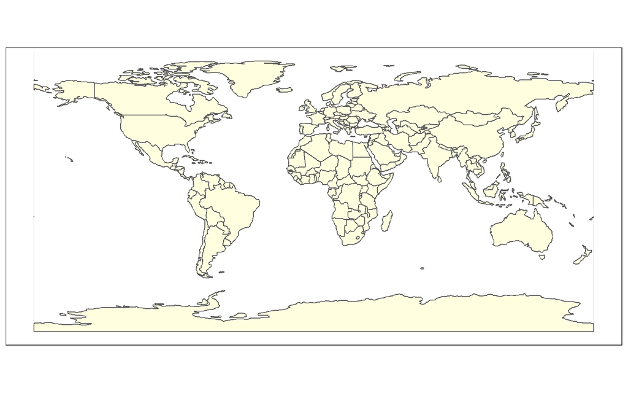

Ce fonds de carte comporte 175 unités spatiales, mais de quoi s’agit-il exactement. Les métadonnées associées permettent de se faire une idée plus précise de la nature exacte de ces unités. Prenons pour cela quelques exempes

|  | sovereignt | sov_a3 | type | admin | adm0_a3 | name | note_adm0 | iso_a3 | wb_a3 | geometry |
| --- | --- | --- | --- | --- | --- | --- | --- | --- | --- | --- |
| 6 | Antarctica | ATA | Indeterminate | Antarctica | ATA | Antarctica | NA | ATA | NA | MULTIPOLYGON (((-59.57209 -… |
| 7 | France | FR1 | Dependency | French Southern and Antarctic Lands | ATF | Fr. S. Antarctic Lands | Fr. | ATF | NA | MULTIPOLYGON (((68.935 -48…. |
| 30 | China | CH1 | Country | China | CHN | China | NA | CHN | CHN | MULTIPOLYGON (((110.3392 18… |
| 55 | France | FR1 | Country | France | FRA | France | NA | FRA | FRA | MULTIPOLYGON (((-52.55642 2… |
| 78 | Israel | ISR | Sovereign country | Israel | ISR | Israel | NA | ISR | ISR | MULTIPOLYGON (((35.71992 32… |
| 99 | Morocco | MAR | Sovereign country | Morocco | MAR | Morocco | NA | MAR | MAR | MULTIPOLYGON (((-5.193863 3… |
| 113 | France | FR1 | Dependency | New Caledonia | NCL | New Caledonia | Fr. | NCL | NCL | MULTIPOLYGON (((165.78 -21…. |
| 128 | United States of America | US1 | Dependency | Puerto Rico | PRI | Puerto Rico | Commonwealth of U.S.A. | PRI | PRI | MULTIPOLYGON (((-66.28243 1… |
| 132 | Israel | ISR | Disputed | Palestine | PSX | Palestine | Partial self-admin. | PSE | WBG | MULTIPOLYGON (((35.54567 32… |
| 137 | Western Sahara | SAH | Indeterminate | Western Sahara | SAH | W. Sahara | Self admin. | ESH | NA | MULTIPOLYGON (((-8.794884 2… |
| 163 | Taiwan | TWN | Sovereign country | Taiwan | TWN | Taiwan | NA | TWN | NA | MULTIPOLYGON (((121.7778 24… |
| 168 | United States of America | US1 | Country | United States of America | USA | United States | NA | USA | USA | MULTIPOLYGON (((-155.5421 1… |

Les exemples présentés dans le tableau ci-dessus montrent la complexité du problème de définition et de représentation cartographique des “pays” ou “bouts du monde”. Quelques remarques :

1. La *France* (FR1) en tant qu’état souverain regroupe ici cartographiquement la partie métropolitaine du pays et les Départements d’Outre-Mer (Guyane Française, Réunion, Martinique, Guadeloupe) en une seule entité spatiale, mais elle met à part la Nouvelle Calédonie et les îles antarctiques.
2. *Porto Rico* (PRI) est considéré comme une dépendance des *Etats-Unis* (US1) au même titre que la *Nouvelle Calédonie*(NCL) est considérée comme une dépendance de la *France* (FR1).
3. Le *Sahara occidental* (SAH) est considéré comme une zone *indéterminée* bien qu’il soit occupé par le *Maroc* (MAR).
4. la Palestine (PSX) est considéré comme une zone *disputée* mais rattachée en terme de souveraineté à *Israël* (ISR) et une note précise qu’elle est *partiellement semi-administrée*. Le code sur trois caractères des territoires palestiniens est très variable selon les organisations (PSX, PSE, WBG).
5. *Taïwan* (TWN) est présenté comme un état souverain, mais son code ISO3 est manquant pour la banque mondiale car la Chine refuse de le reconnaître.
6. Plusieurs états souverains de petite taille sont absents de ce fonds de carte qui ne regroupe que 175 unités soit moins que les 193 pays membres des Nations-Unies. La plupart des îles du Pacifique sont en particulier éliminées car leur surface les rendrait invisible pour le degré de généralisation cartographique adopté.

### 1.2.3 le fonds de carte *sovereignty110* (171 unités)

On peut obtenir un fonds différent en installant le package complémentaire `rnaturalearthdata` qui permet notamment de distinguer le fonds de carte des *countries* (c’est-à-dire des “bouts du monde” souverains ou non) et des *sovereignty* (c’est-à-dire des états souverains)

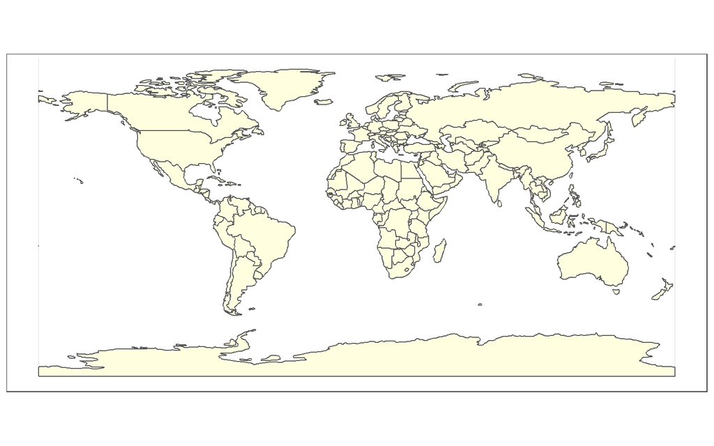

Le fonds de carte permet désormais de récupérer la plupart des pays souverains du Monde, y compris les petits états insulaires du Pacifique, mais il fait disparaître de façon sélective les territoires indéterminés ou disputés. Ainsi, le Sahra Occidental demeure partiellement séparé du Maroc mais les territoires palestiniens sont annexés à Israël ainsi que le plateau du Golan ce qui n’est évidemment pas un choix neutred’un point de vue géoolitique.

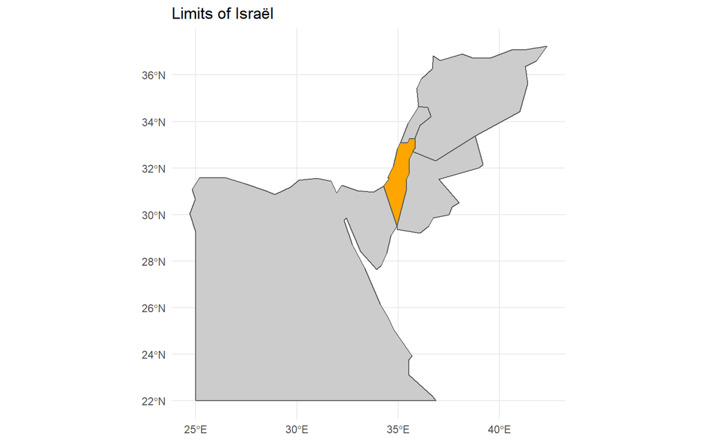

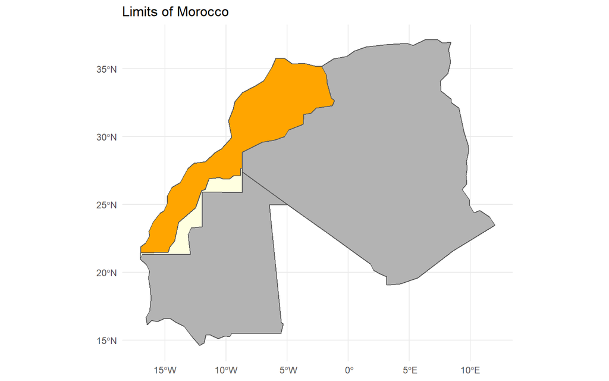

### 1.2.4 Le fonds de carte *countries50*

On peut également choisir un fonds moins généralisé dans lequel tous les petits pays seront présents

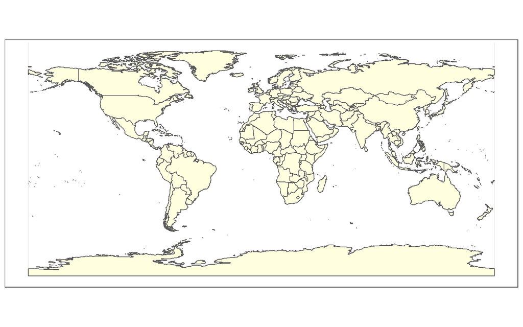

Il existe toute une série d’autres fonds de carte dans le package Natural Earth, notamment avec des résolutions plus précises, mais on se limitera ici à l’exploration des fonds de carte utile pour produire des cartes à contour généralisé couvrant le monde entier.

## 1.3 Exemple d’application

Nous allons essayer de constituer une carte des émissions de CO2 par habitant des pays de la CEDEAO en 2018 basée sur la combinaison des données `wbstats` et du fonds de carte `naturalearth`.

### 1.3.1 Etape 1 : récupération des données statistiques

| iso2c | iso3c | country | date | EN.ATM.CO2E.KT | SP.POP.TOTL |
| --- | --- | --- | --- | --- | --- |
| BJ | BEN | Benin | 2018 | 7910 | 11485035 |
| BF | BFA | Burkina Faso | 2018 | 4270 | 19751466 |
| CI | CIV | Cote d’Ivoire | 2018 | 9910 | 25069226 |
| CV | CPV | Cabo Verde | 2018 | 620 | 543764 |
| GH | GHA | Ghana | 2018 | 16110 | 29767108 |
| GN | GIN | Guinea | 2018 | 3120 | 12414292 |
| GM | GMB | Gambia, The | 2018 | 570 | 2280092 |
| GW | GNB | Guinea-Bissau | 2018 | 310 | 1874304 |
| LR | LBR | Liberia | 2018 | 1320 | 4818976 |
| ML | MLI | Mali | 2018 | 5620 | 19077755 |
| NE | NER | Niger | 2018 | 2290 | 22442831 |
| NG | NGA | Nigeria | 2018 | 130670 | 195874685 |
| SN | SEN | Senegal | 2018 | 9860 | 15854324 |
| SL | SLE | Sierra Leone | 2018 | 1020 | 7650149 |
| TG | TGO | Togo | 2018 | 2260 | 7889095 |

Nous renommons les variables pour avoir un tableau plus simple ou la population est en millions d’habitants, les émissions de CO2 en millions de tonnes. On y ajoute l’intensité des émissions en tonnes par habitant.

| ISO3 | NOM | POP | CO2 | CO2_hab |
| --- | --- | --- | --- | --- |
| BEN | Benin | 11.49 | 7.91 | 0.69 |
| BFA | Burkina Faso | 19.75 | 4.27 | 0.22 |
| CIV | Cote d’Ivoire | 25.07 | 9.91 | 0.40 |
| CPV | Cabo Verde | 0.54 | 0.62 | 1.14 |
| GHA | Ghana | 29.77 | 16.11 | 0.54 |
| GIN | Guinea | 12.41 | 3.12 | 0.25 |
| GMB | Gambia, The | 2.28 | 0.57 | 0.25 |
| GNB | Guinea-Bissau | 1.87 | 0.31 | 0.17 |
| LBR | Liberia | 4.82 | 1.32 | 0.27 |
| MLI | Mali | 19.08 | 5.62 | 0.29 |
| NER | Niger | 22.44 | 2.29 | 0.10 |
| NGA | Nigeria | 195.87 | 130.67 | 0.67 |
| SEN | Senegal | 15.85 | 9.86 | 0.62 |
| SLE | Sierra Leone | 7.65 | 1.02 | 0.13 |
| TGO | Togo | 7.89 | 2.26 | 0.29 |

### 1.3.2 Etape 2 : Récupération du fonds de carte

on récupère ensuite le fonds de carte en ne gardant que les pays de la CEDEAO

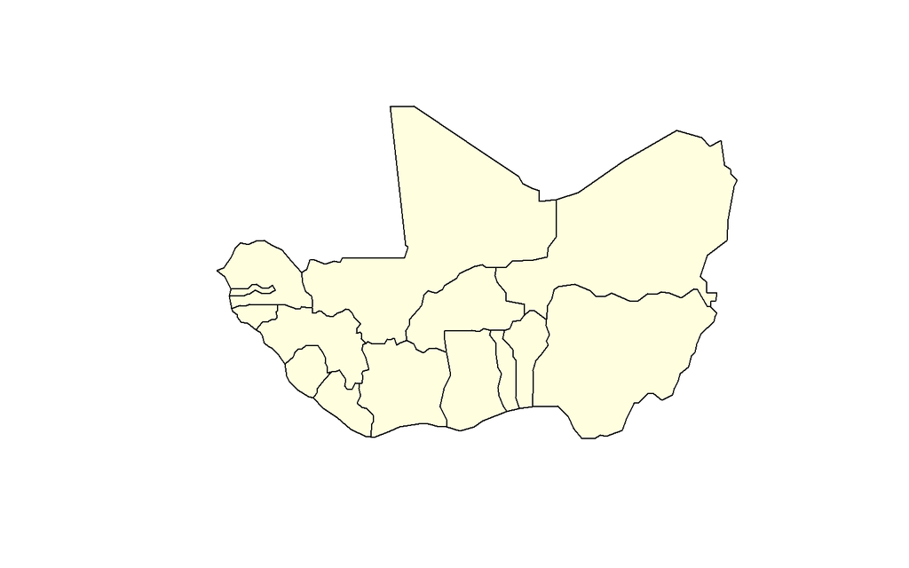

### 1.3.3 Etape 3 : Jointure du fonds de carte et des statistiques

| ISO3 | NOM | POP | CO2 | CO2_hab | geometry |
| --- | --- | --- | --- | --- | --- |
| BEN | Benin | 11.485035 | 7.91 | 0.6887223 | MULTIPOLYGON (((2.691702 6…. |
| BFA | Burkina Faso | 19.751466 | 4.27 | 0.2161865 | MULTIPOLYGON (((-2.827496 9… |
| CIV | Cote d’Ivoire | 25.069226 | 9.91 | 0.3953054 | MULTIPOLYGON (((-2.856125 4… |
| GHA | Ghana | 29.767108 | 16.11 | 0.5412014 | MULTIPOLYGON (((1.060122 5…. |
| GIN | Guinea | 12.414292 | 3.12 | 0.2513232 | MULTIPOLYGON (((-8.439298 7… |
| GMB | Gambia, The | 2.280092 | 0.57 | 0.2499899 | MULTIPOLYGON (((-16.84152 1… |

### 1.3.4 Etape 4 : Visualisation avec mapsf

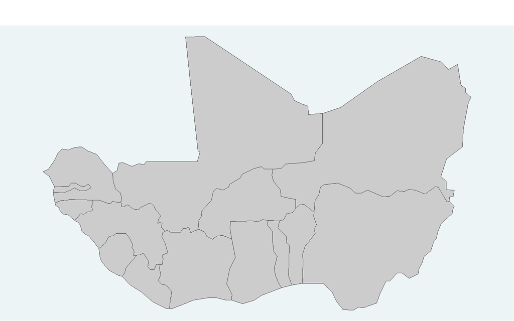

[figure not shown]

# Bibliographie

BARNIER, Julien, 2021. *rmdformats: HTML Output Formats and Templates for ’rmarkdown’ Documents* [en ligne]. S.l. : s.n. Disponible à l'adresse : https://github.com/juba/rmdformats.

R CORE TEAM, 2020. *R: A Language and Environment for Statistical Computing* [en ligne]. Vienna, Austria : R Foundation for Statistical Computing. Disponible à l'adresse : https://www.R-project.org/.

XIE, Yihui, 2020. *knitr: A General-Purpose Package for Dynamic Report Generation in R* [en ligne]. S.l. : s.n. Disponible à l'adresse : https://CRAN.R-project.org/package=knitr.

# Annexes

## Infos session

| setting | value |
| --- | --- |
| version | R version 4.1.0 (2021-05-18) |
| os | Windows 10 x64 |
| system | x86_64, mingw32 |
| ui | RTerm |
| language | (EN) |
| collate | French_France.1252 |
| ctype | French_France.1252 |
| tz | Europe/Paris |
| date | 2021-12-17 |

| package | ondiskversion | source |
| --- | --- | --- |
| cowplot | 1.1.1 | CRAN (R 4.1.1) |
| data.table | 1.14.0 | CRAN (R 4.1.0) |
| dplyr | 1.0.6 | CRAN (R 4.1.0) |
| DT | 0.18 | CRAN (R 4.1.0) |
| FactoMineR | 2.4 | CRAN (R 4.1.0) |
| ggplot2 | 3.3.3 | CRAN (R 4.1.0) |
| knitr | 1.34 | CRAN (R 4.1.1) |
| leaflet | 2.0.4.1 | CRAN (R 4.1.1) |
| mapsf | 0.2.0 | CRAN (R 4.1.0) |
| mapview | 2.10.0 | CRAN (R 4.1.1) |
| rmarkdown | 2.11 | CRAN (R 4.1.1) |
| rnaturalearth | 0.1.0 | CRAN (R 4.1.2) |
| rnaturalearthdata | 0.1.0 | CRAN (R 4.1.2) |
| rzine | 0.1.0 | gitlab (rzine/package@a94bf55) |
| sf | 1.0.0 | CRAN (R 4.1.0) |
| stargazer | 5.2.2 | CRAN (R 4.1.0) |
| tidyr | 1.1.3 | CRAN (R 4.1.0) |
| wbstats | 1.0.4 | CRAN (R 4.1.2) |

## Citation

[output not shown]